# Playstore Apps (Classification Problem)

## Feature Selection

Split the dataset to train and test set

```r
names(playstore)
```

```
##  [1] "Offered_By"                     "Category"
##  [3] "Rating"                         "Reviews"
##  [5] "Size"                           "Price"
##  [7] "Content_Rating"                 "Last_Updated_On"
##  [9] "Release_Version"                "OS_Version_Required"
## [11] "Downloads"                      "Major_Version"
## [13] "OS_Version_Numeric"             "newCategory"
## [15] "Cluster"                        "Merged_Category"
## [17] "Class"                          "Reviews_log"
## [19] "Content_Rating_Everyone"        "Content_Rating_Everyone_10plus"
## [21] "Content_Rating_Mature_17plus"   "Content_Rating_Teen"
## [23] "Content_Rating_Unrated"
```

```r
# Create the training dataset
train.X <- playstore[train_indices, c("Rating", "Reviews", "Price", "Last_Updated_On", "Cluster",
                                       "Content_Rating_Everyone",
                                      "Content_Rating_Everyone_10plus", "Content_Rating_Mature_17plus",
                                      "Content_Rating_Teen", "Content_Rating_Unrated", "Major_Version",
                                      "OS_Version_Numeric")]

train.Class <- playstore$Class[train_indices]

# Create the test dataset (the rest of the data not included in the training set)
test.X <- playstore[-train_indices, c("Rating", "Reviews", "Price", "Last_Updated_On", "Cluster",
                                       "Content_Rating_Everyone",
                                      "Content_Rating_Everyone_10plus", "Content_Rating_Mature_17plus",
                                      "Content_Rating_Teen", "Content_Rating_Unrated", "Major_Version",
                                      "OS_Version_Numeric")]


test.Class <- playstore$Class[-train_indices]
```

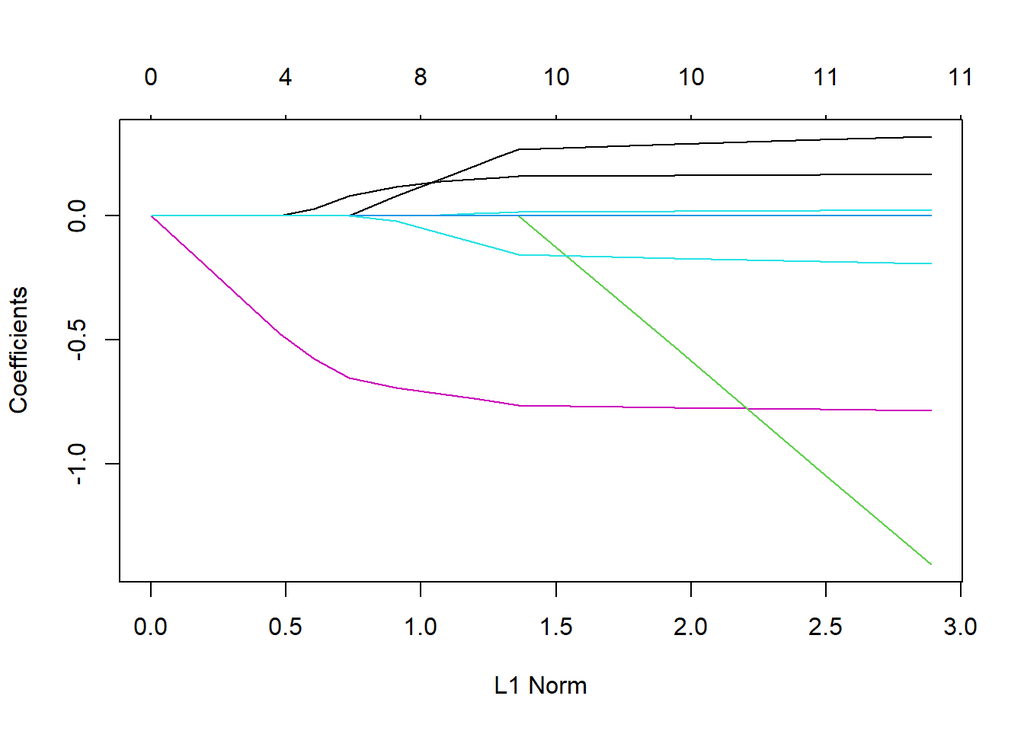

```r
train.X.matrix <- as.matrix(train.X)
test.X.matrix <- as.matrix(test.X)
train.Class <- as.numeric(train.Class)

grid <- 10^seq(10, -2, length = 100)
# alpha = 1 for Lasso regression
lasso.mod <- glmnet(train.X.matrix, train.Class, alpha = 1, lambda = grid)
plot(lasso.mod)
```

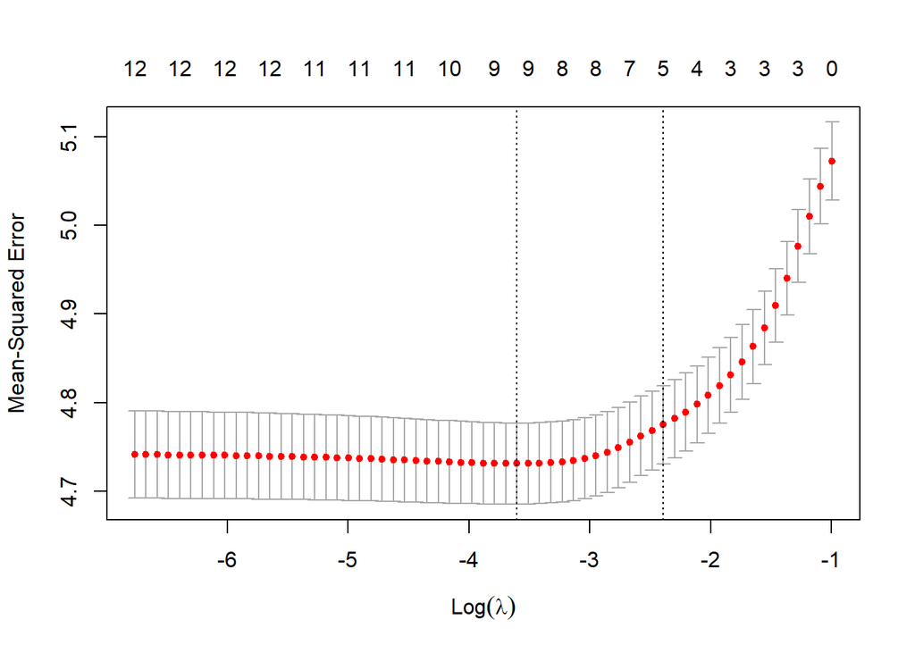

```r
set.seed(3)
# Alpha set to 1 for LASSO regression
# Fit the LASSO regression model using cross-validation to find the optimal lambda
cv.lasso <- cv.glmnet(train.X.matrix, train.Class, alpha = 1)

plot(cv.lasso)
```

```r
# The best lambda value found by cross-validation
(best_lambda_lasso <- cv.lasso$lambda.min)
```

```
## [1] 0.02727942
```

```r
# Fit the final LASSO regression model using the best lambda
final.lasso.model <- glmnet(train.X.matrix, train.Class, alpha = 1, lambda = best_lambda_lasso)

# To make predictions on the test set
lasso.coef <- predict(final.lasso.model, type="coefficients", s = best_lambda_lasso)[1:13,]
lasso.coef[lasso.coef != 0]
```

```
##                    (Intercept)                         Rating
##                   2.396512e+00                   1.562242e-01
##                        Reviews                          Price
##                   1.633623e-07                  -1.217075e-04
##                Last_Updated_On                        Cluster
##                   7.504517e-04                   1.329198e-02
##        Content_Rating_Everyone Content_Rating_Everyone_10plus
##                  -7.562256e-01                   2.500900e-01
##                  Major_Version             OS_Version_Numeric
##                   4.837691e-09                  -1.432558e-01
```

After conducting LASSO regression analysis on our dataset, we have identified several key predictors that are instrumental in determining the outcome. The important features that the LASSO model selected include `Reviews`, `Price`, `Rating`, `Last_Updated_On`, `Cluster`, `Content_Rating_Everyone`, `Content_Rating_Everyone_10plus`, `Major_Version`, and `OS_Version_Numeric`. Thus, we use all the predictors since the ones that are not important are dummy variables of the `Content_Rating`.

## Model

KNN- Let’s try to see what results we get if we fit a KNN model with k=1

```r
knn.pred <- knn(train.X, test.X, train.Class, k = 1)
cm<-table(knn.pred, test.Class)
cm
```

```
##         test.Class
## knn.pred   0   1   2   3   4   5   6   7
##        1 347 114   4   3   0   0   0   0
##        2  89 356  83  87   2   1   0   0
##        3   4  76  61  73   8   4   0   0
##        4   2  77  94 294  90  64   2   2
##        5   0   6  17 115  76  63   4   3
##        6   0   2   4  68  88 276  59  28
##        7   0   0   0   2  11  65  51  53
##        8   0   0   2   0   4  49  42 279
```

```r
accuracy <- sum(diag(cm)) / sum(cm)
accuracy
```

```
## [1] 0.5266344
```

```r
precision <- recall <- f1_score <- rep(NA, nrow(cm))

for (i in 1:nrow(cm)) {
  tp <- cm[i, i]
  fp <- sum(cm[-i, i])
  fn <- sum(cm[i, -i])
  precision[i] <- tp / (tp + fp)
  recall[i] <- tp / (tp + fn)
  f1_score[i] <- ifelse((precision[i] + recall[i]) == 0, 0,
                        (2 * precision[i] * recall[i]) / (precision[i] + recall[i]))
}

# Macro-average calculations (simple average across classes)
macro_precision <- mean(precision, na.rm = TRUE)
macro_recall <- mean(recall, na.rm = TRUE)
macro_f1_score <- mean(f1_score, na.rm = TRUE)

# Output the metrics
cat("Accuracy:", accuracy, "\n")
```

```
## Accuracy: 0.5266344
```

```r
cat("Macro Precision:", macro_precision, "\n")
```

```
## Macro Precision: 0.4907112
```

```r
cat("Macro Recall:", macro_recall, "\n")
```

```
## Macro Recall: 0.4841722
```

```r
cat("Macro F1 Score:", macro_f1_score, "\n")
```

```
## Macro F1 Score: 0.4869367
```

KNN with k = 5 (avoid overfitting).

```r
knn.pred <- knn(train.X, test.X, train.Class, k = 5)
cm<-table(knn.pred, test.Class)
cm
```

```
##         test.Class
## knn.pred   0   1   2   3   4   5   6   7
##        1 356 103   1   1   0   0   0   0
##        2  83 399 101  64   1   1   0   0
##        3   2  53  41  58   3   2   0   0
##        4   0  70 109 367 101  56   3   2
##        5   0   4  10  92  67  48   2   1
##        6   1   2   3  58 102 323  63  38
##        7   0   0   0   2   3  55  42  36
##        8   0   0   0   0   2  37  48 288
```

```r
accuracy <- sum(diag(cm)) / sum(cm)
accuracy
```

```
## [1] 0.5699153
```

```r
precision <- recall <- f1_score <- rep(NA, nrow(cm))

for (i in 1:nrow(cm)) {
  tp <- cm[i, i]
  fp <- sum(cm[-i, i])
  fn <- sum(cm[i, -i])
  precision[i] <- tp / (tp + fp)
  recall[i] <- tp / (tp + fn)
  f1_score[i] <- ifelse((precision[i] + recall[i]) == 0, 0,
                        (2 * precision[i] * recall[i]) / (precision[i] + recall[i]))
}

# Macro-average calculations (simple average across classes)
macro_precision <- mean(precision, na.rm = TRUE)
macro_recall <- mean(recall, na.rm = TRUE)
macro_f1_score <- mean(f1_score, na.rm = TRUE)

# Output the metrics
cat("Accuracy:", accuracy, "\n")
```

```
## Accuracy: 0.5699153
```

```r
cat("Macro Precision:", macro_precision, "\n")
```

```
## Macro Precision: 0.5097386
```

```r
cat("Macro Recall:", macro_recall, "\n")
```

```
## Macro Recall: 0.5102703
```

```r
cat("Macro F1 Score:", macro_f1_score, "\n")
```

```
## Macro F1 Score: 0.5073149
```

We have better scores when we fit our model with k=5 than k=1.

KNN with k = 10 (avoid overfitting).

```r
knn.pred <- knn(train.X, test.X, train.Class, k = 10)
cm<-table(knn.pred, test.Class)
cm
```

```
##         test.Class
## knn.pred   0   1   2   3   4   5   6   7
##        1 358 105   1   0   0   0   0   0
##        2  82 412  99  67   1   0   0   0
##        3   1  39  31  39   2   1   0   0
##        4   0  70 125 412 103  57   2   3
##        5   0   4   6  67  66  46   1   1
##        6   1   1   3  56 105 343  77  39
##        7   0   0   0   1   1  48  35  32
##        8   0   0   0   0   1  27  43 290
```

```r
accuracy <- sum(diag(cm)) / sum(cm)
accuracy
```

```
## [1] 0.5892857
```

```r
precision <- recall <- f1_score <- rep(NA, nrow(cm))

for (i in 1:nrow(cm)) {
  tp <- cm[i, i]
  fp <- sum(cm[-i, i])
  fn <- sum(cm[i, -i])
  precision[i] <- tp / (tp + fp)
  recall[i] <- tp / (tp + fn)
  f1_score[i] <- ifelse((precision[i] + recall[i]) == 0, 0,
                        (2 * precision[i] * recall[i]) / (precision[i] + recall[i]))
}

# Macro-average calculations (simple average across classes)
macro_precision <- mean(precision, na.rm = TRUE)
macro_recall <- mean(recall, na.rm = TRUE)
macro_f1_score <- mean(f1_score, na.rm = TRUE)

# Output the metrics
cat("Accuracy:", accuracy, "\n")
```

```
## Accuracy: 0.5892857
```

```r
cat("Macro Precision:", macro_precision, "\n")
```

```
## Macro Precision: 0.5164124
```

```r
cat("Macro Recall:", macro_recall, "\n")
```

```
## Macro Recall: 0.5249605
```

```r
cat("Macro F1 Score:", macro_f1_score, "\n")
```

```
## Macro F1 Score: 0.5133999
```

We have even better scores. With k=10 we have better scores than k=5, which has better scores than k=1.

```r
train.X <- playstore[train_indices, c("Rating", "Reviews", "Price", "Last_Updated_On", "Cluster",
                                      "Content_Rating_Everyone",
                                      "Content_Rating_Everyone_10plus", "Content_Rating_Mature_17plus",
                                      "Content_Rating_Teen", "Content_Rating_Unrated", "Major_Version",
                                      "OS_Version_Numeric")]

train.Class <- playstore$Class[train_indices]

# Create the test dataset (the rest of the data not included in the training set)
test.X <- playstore[-train_indices, c("Rating", "Reviews", "Price", "Last_Updated_On", "Cluster",
                                       "Content_Rating_Everyone",
                                      "Content_Rating_Everyone_10plus", "Content_Rating_Mature_17plus",
                                      "Content_Rating_Teen", "Content_Rating_Unrated", "Major_Version",
                                      "OS_Version_Numeric")]


test.Class <- playstore$Class[-train_indices]
```

Random Forest

```r
rf.model <- randomForest(x = train.X, y = train.Class, ntree = 500, mtry = 3, importance = TRUE)

importance(rf.model)
```

```
##                                          0          1          2          3
## Rating                         26.40480694  28.073304  8.9819530 36.0669845
## Reviews                        92.40650211 103.607426 56.4934838 97.6862454
## Price                          54.34258123  66.092655 30.3139477 68.2823563
## Last_Updated_On                14.78664743  20.497168  1.9348389 25.0258118
## Cluster                        14.60667954  18.100371  1.2122147 24.4392597
## Content_Rating_Everyone         3.01412756  13.067419 -3.7433651 13.6977813
## Content_Rating_Everyone_10plus  6.33067938  10.128479 -4.5299829  3.1965841
## Content_Rating_Mature_17plus   -0.09746553   5.043074  3.8610021  1.2796752
## Content_Rating_Teen             7.80273202   7.234276 -0.6104750 10.3874207
## Content_Rating_Unrated          0.00000000   0.000000  0.0000000  0.0000000
## Major_Version                   5.10278242  11.626357  0.1416007  0.4149594
## OS_Version_Numeric              3.91663310   9.382658  3.0344853 13.2553543
##                                         4          5         6         7
## Rating                          8.5604136 32.5767116 24.050063 24.678257
## Reviews                        53.1764438 94.3812998 60.983867 99.454130
## Price                          28.6608590 56.4454116 30.031799 36.154686
## Last_Updated_On                 5.6829741 13.1396377 11.504889 19.661299
## Cluster                        -0.8869642 23.2859284 14.587802 10.981164
## Content_Rating_Everyone         2.5506241  5.9169456 14.395973  9.170960
## Content_Rating_Everyone_10plus -1.0436234 -1.2019181  4.009498 -4.228723
## Content_Rating_Mature_17plus    1.7375929  0.9226955  2.985253 -3.024293
## Content_Rating_Teen             0.6624644  6.5259184 11.595954  2.527010
## Content_Rating_Unrated          0.0000000  0.0000000  0.000000  0.000000
## Major_Version                   4.7140773 10.0740839 19.495355  9.374526
## OS_Version_Numeric              4.5653193 18.1316207 10.091190 15.511674
##                                MeanDecreaseAccuracy MeanDecreaseGini
## Rating                                    67.450113     1002.1931965
## Reviews                                  116.260466     4486.3623804
## Price                                     95.438454      212.0893181
## Last_Updated_On                           40.478619      809.2107826
## Cluster                                   40.306968      136.4835782
## Content_Rating_Everyone                   21.020151       65.3676904
## Content_Rating_Everyone_10plus             5.295458       34.7406766
## Content_Rating_Mature_17plus               4.095710       30.6503058
## Content_Rating_Teen                       15.683512       48.0489066
## Content_Rating_Unrated                     0.000000        0.4121435
## Major_Version                             19.388881      361.5229468
## OS_Version_Numeric                        28.032757      349.3659898
```

```r
# Use the Random Forest model to make predictions on the test dataset
rf.pred <- predict(rf.model, newdata = test.X)

# Create a confusion matrix with the predictions and the true class labels
cm <- table(rf.pred, test.Class)
cm
```

```
##        test.Class
## rf.pred   0   1   2   3   4   5   6   7
##       0 372  78   0   0   0   0   0   0
##       1  70 496 109  63   0   0   0   0
##       2   0   3  12   6   0   0   0   0
##       3   0  54 144 520 135  66   1   4
##       4   0   0   0  11  19   6   0   0
##       5   0   0   0  42 125 427  93  46
##       6   0   0   0   0   0   4  18  18
##       7   0   0   0   0   0  19  46 297
```

```r
# Calculate accuracy
accuracy <- sum(diag(cm)) / sum(cm)

# Calculate precision, recall, and F1 score for each class
precision <- recall <- f1_score <- rep(NA, nrow(cm))
for (i in 1:nrow(cm)) {
  tp <- cm[i, i]
  fp <- sum(cm[-i, i])
  fn <- sum(cm[i, -i])
  precision[i] <- tp / (tp + fp)
  recall[i] <- tp / (tp + fn)
  f1_score[i] <- ifelse((precision[i] + recall[i]) == 0, 0,
                        (2 * precision[i] * recall[i]) / (precision[i] + recall[i]))
}

# Macro-average calculations (simple average across classes)
macro_precision <- mean(precision, na.rm = TRUE)
macro_recall <- mean(recall, na.rm = TRUE)
macro_f1_score <- mean(f1_score, na.rm = TRUE)

# Output the metrics
cat("Accuracy:", accuracy, "\n")
```

```
## Accuracy: 0.6540557
```

```r
cat("Macro Precision:", macro_precision, "\n")
```

```
## Macro Precision: 0.5370832
```

```r
cat("Macro Recall:", macro_recall, "\n")
```

```
## Macro Recall: 0.6267137
```

```r
cat("Macro F1 Score:", macro_f1_score, "\n")
```

```
## Macro F1 Score: 0.5133392
```

By checking the Mean Decrease Accuracy the 5 most important predictors are `Reviews`, `Price`, `Rating`, `Cluster` and `Last_Updated_On`. For the Mean Decrease Gini the 5 most important predictors are `Reviews`, `Rating`, `Last_Updated_On`, `Major_Version` and `OS_Version_Numeric`.  
Reviews seems to be the most important in both metrics and it confirms our corellation matrix’s indication that it is highly correlated with `Downloads`. We fit again Random Forest with the 3 common important predictors.

```r
rf.model <- randomForest(Class ~  Reviews + Last_Updated_On + Rating, data = playstore, subset = train_indices)

# Use the Random Forest model to make predictions on the test dataset
rf.pred <- predict(rf.model, newdata = test.X)

# Create a confusion matrix with the predictions and the true class labels
cm <- table(rf.pred, test.Class)
cm
```

```
##        test.Class
## rf.pred   0   1   2   3   4   5   6   7
##       0 352  92   0   0   0   0   0   0
##       1  88 417 111  79   1   0   0   0
##       2   1  47  29  43   1   1   0   0
##       3   1  73 121 419 104  53   0   1
##       4   0   2   3  54  60  48   1   1
##       5   0   0   1  47 112 362  70  37
##       6   0   0   0   0   1  34  44  18
##       7   0   0   0   0   0  24  43 308
```

```r
# Calculate accuracy
accuracy <- sum(diag(cm)) / sum(cm)

# Calculate precision, recall, and F1 score for each class
precision <- recall <- f1_score <- rep(NA, nrow(cm))
for (i in 1:nrow(cm)) {
  tp <- cm[i, i]
  fp <- sum(cm[-i, i])
  fn <- sum(cm[i, -i])
  precision[i] <- tp / (tp + fp)
  recall[i] <- tp / (tp + fn)
  f1_score[i] <- ifelse((precision[i] + recall[i]) == 0, 0,
                        (2 * precision[i] * recall[i]) / (precision[i] + recall[i]))
}

# Macro-average calculations (simple average across classes)
macro_precision <- mean(precision, na.rm = TRUE)
macro_recall <- mean(recall, na.rm = TRUE)
macro_f1_score <- mean(f1_score, na.rm = TRUE)

# Output the metrics
cat("Accuracy:", accuracy, "\n")
```

```
## Accuracy: 0.6026029
```

```r
cat("Macro Precision:", macro_precision, "\n")
```

```
## Macro Precision: 0.5312718
```

```r
cat("Macro Recall:", macro_recall, "\n")
```

```
## Macro Recall: 0.5472337
```

```r
cat("Macro F1 Score:", macro_f1_score, "\n")
```

```
## Macro F1 Score: 0.5299987
```

Let’s try with a binary response variable. The threshold that we will use is 0.5.

```r
num_classes <- 2 # Create balanced classes
# Determine the range cut-offs based on quantiles
quantiles <- quantile(playstore$Downloads, probs = seq(0, 1, length.out = num_classes + 1), na.rm = TRUE)
quantiles
```

```
##    0%   50%  100%
## 1e+01 1e+05 5e+09
```

```r
# Assign each observation to a class based on these cut-offs
playstore <- playstore %>%
  mutate(Class = cut(Downloads, breaks = quantiles, labels = FALSE, include.lowest = TRUE))
playstore$Class <- playstore$Class -1
class_summary <- playstore %>%
  group_by(Class) %>%
  summarise(
    Min_Downloads = min(Downloads),
    Max_Downloads = max(Downloads),
    Count = n()
  )
class_summary
```

```
## # A tibble: 2 × 4
##   Class Min_Downloads Max_Downloads Count
##   <dbl>         <dbl>         <dbl> <int>
## 1     0            10        100000  9671
## 2     1        500000    5000000000  6845
```

```r
playstore$Class <- ifelse(playstore$Class==0, 'Not Popular', 'Popular')
playstore$Class <- as.factor(playstore$Class)
table(playstore$Class)
```

```
##
## Not Popular     Popular
##        9671        6845
```

Logistic Regression - We fit a logistic regression model using the predictors of the feature selection.

```r
test.set <-playstore[-train_indices, ]
test.Class <- playstore$Class[-train_indices]

glm.fits <- glm(
  Class ~  Reviews + Last_Updated_On + Cluster + Rating + Price + Content_Rating_Everyone +Content_Rating_Teen+ Content_Rating_Mature_17plus+ OS_Version_Numeric + Major_Version +Content_Rating_Unrated+ Content_Rating_Everyone_10plus, family = binomial, data = playstore, subset = train_indices)
summary(glm.fits)
```

```
##
## Call:
## glm(formula = Class ~ Reviews + Last_Updated_On + Cluster + Rating +
##     Price + Content_Rating_Everyone + Content_Rating_Teen + Content_Rating_Mature_17plus +
##     OS_Version_Numeric + Major_Version + Content_Rating_Unrated +
##     Content_Rating_Everyone_10plus, family = binomial, data = playstore,
##     subset = train_indices)
##
## Coefficients:
##                                  Estimate Std. Error z value Pr(>|z|)
## (Intercept)                     1.156e+01  8.531e+02   0.014   0.9892
## Reviews                         4.849e-04  1.134e-05  42.766  < 2e-16 ***
## Last_Updated_On                 5.058e-04  1.178e-04   4.295 1.75e-05 ***
## Cluster                        -3.914e-01  5.312e-02  -7.367 1.74e-13 ***
## Rating                         -9.515e-02  9.785e-02  -0.972   0.3308
## Price                          -2.961e-02  1.742e-03 -17.001  < 2e-16 ***
## Content_Rating_Everyone        -1.342e+01  8.531e+02  -0.016   0.9874
## Content_Rating_Teen            -1.388e+01  8.531e+02  -0.016   0.9870
## Content_Rating_Mature_17plus   -1.331e+01  8.531e+02  -0.016   0.9876
## OS_Version_Numeric             -2.463e-01  6.011e-02  -4.097 4.19e-05 ***
## Major_Version                   1.149e-07  5.037e-08   2.282   0.0225 *
## Content_Rating_Unrated         -2.618e+01  1.687e+03  -0.016   0.9876
## Content_Rating_Everyone_10plus -1.400e+01  8.531e+02  -0.016   0.9869
## ---
## Signif. codes:  0 '***' 0.001 '**' 0.01 '*' 0.05 '.' 0.1 ' ' 1
##
## (Dispersion parameter for binomial family taken to be 1)
##
##     Null deviance: 17957.7  on 13211  degrees of freedom
## Residual deviance:  5478.1  on 13199  degrees of freedom
## AIC: 5504.1
##
## Number of Fisher Scoring iterations: 14
```

```r
glm.probs <- predict(glm.fits, test.set,
                     type = "response")

glm.pred <- rep("Not Popular", nrow(test.set))
glm.pred[glm.probs > .5] <- "Popular"
lg<- table(glm.pred, test.Class)
lg
```

```
##              test.Class
## glm.pred      Not Popular Popular
##   Not Popular        1917     181
##   Popular              63    1143
```

```r
accuracy <- sum(diag(lg)) / sum(lg)
mean(glm.pred == test.Class)
```

```
## [1] 0.9261501
```

```r
contrasts(playstore$Class)
```

```
##             Popular
## Not Popular       0
## Popular           1
```

```r
precision <- recall <- f1_score <- rep(NA, nrow(lg))

for (i in 1:nrow(lg)) {
  tp <- lg[i, i]
  fp <- sum(lg[-i, i])
  fn <- sum(lg[i, -i])
  precision[i] <- tp / (tp + fp)
  recall[i] <- tp / (tp + fn)
  f1_score[i] <- ifelse((precision[i] + recall[i]) == 0, 0,
                        (2 * precision[i] * recall[i]) / (precision[i] + recall[i]))
}

# Macro-average calculations (simple average across classes)
macro_precision <- mean(precision, na.rm = TRUE)
macro_recall <- mean(recall, na.rm = TRUE)
macro_f1_score <- mean(f1_score, na.rm = TRUE)
results <- c()
results$lg <- accuracy

results_f1 <- c()
results_f1$lg <- macro_f1_score

# Output the metrics
cat("Accuracy:", accuracy, "\n")
```

```
## Accuracy: 0.9261501
```

```r
cat("Macro Precision:", macro_precision, "\n")
```

```
## Macro Precision: 0.9157374
```

```r
cat("Macro Recall:", macro_recall, "\n")
```

```
## Macro Recall: 0.9307443
```

```r
cat("Macro F1 Score:", macro_f1_score, "\n")
```

```
## Macro F1 Score: 0.921862
```

We observe high scores: All metrics are above the 0.90

Interaction terms - Fit a logistic regression model with the same predictors as before, but now we add an interaction term of ‘Reviews’ and ‘Last_Updated_On’

```r
glm.fits <- glm(
  Class ~  Reviews*Last_Updated_On + Cluster + Rating + Price + Content_Rating_Everyone +Content_Rating_Teen+ Content_Rating_Mature_17plus+ OS_Version_Numeric + Major_Version +Content_Rating_Unrated+ Content_Rating_Everyone_10plus, family = binomial, data = playstore, subset = train_indices
)
glm.probs <- predict(glm.fits, test.set,
                     type = "response")


glm.pred <- rep("Not Popular", nrow(test.set))
glm.pred[glm.probs > .5] <- "Popular"
lg<- table(glm.pred, test.Class)
lg
```

```
##              test.Class
## glm.pred      Not Popular Popular
##   Not Popular        1919     184
##   Popular              61    1140
```

```r
accuracy <- sum(diag(lg)) / sum(lg)
accuracy
```

```
## [1] 0.9258475
```

```r
mean(glm.pred == test.Class)
```

```
## [1] 0.9258475
```

```r
contrasts(playstore$Class)
```

```
##             Popular
## Not Popular       0
## Popular           1
```

```r
precision <- recall <- f1_score <- rep(NA, nrow(lg))

for (i in 1:nrow(lg)) {
  tp <- lg[i, i]
  fp <- sum(lg[-i, i])
  fn <- sum(lg[i, -i])
  precision[i] <- tp / (tp + fp)
  recall[i] <- tp / (tp + fn)
  f1_score[i] <- ifelse((precision[i] + recall[i]) == 0, 0,
                        (2 * precision[i] * recall[i]) / (precision[i] + recall[i]))
}

# Macro-average calculations (simple average across classes)
macro_precision <- mean(precision, na.rm = TRUE)
macro_recall <- mean(recall, na.rm = TRUE)
macro_f1_score <- mean(f1_score, na.rm = TRUE)
results$lgint <- accuracy

results_f1$lgint <- macro_f1_score

# Output the metrics
cat("Accuracy:", accuracy, "\n")
```

```
## Accuracy: 0.9258475
```

```r
cat("Macro Precision:", macro_precision, "\n")
```

```
## Macro Precision: 0.9151096
```

```r
cat("Macro Recall:", macro_recall, "\n")
```

```
## Macro Recall: 0.9308575
```

```r
cat("Macro F1 Score:", macro_f1_score, "\n")
```

```
## Macro F1 Score: 0.9214827
```

We have similar scores when we use logistic regression with interaction term and without it.

LDA - Very low accuracy compare to Logistic Regression

```r
lda.fit <- lda( Class ~  Reviews + Last_Updated_On + Cluster + Rating + Price + Content_Rating_Everyone +Content_Rating_Teen+Content_Rating_Mature_17plus+ OS_Version_Numeric + Major_Version +Content_Rating_Unrated+ Content_Rating_Everyone_10plus, family = binomial, data = playstore, subset = train_indices )
lda.fit
```

```
## Call:
## lda(Class ~ Reviews + Last_Updated_On + Cluster + Rating + Price +
##     Content_Rating_Everyone + Content_Rating_Teen + Content_Rating_Mature_17plus +
##     OS_Version_Numeric + Major_Version + Content_Rating_Unrated +
##     Content_Rating_Everyone_10plus, data = playstore, family = binomial,
##     subset = train_indices)
##
## Prior probabilities of groups:
## Not Popular     Popular
##   0.5821223   0.4178777
##
## Group means:
##                Reviews Last_Updated_On  Cluster   Rating     Price
## Not Popular   1228.917        2989.015 2.994019 4.226551 50.694618
## Popular     453604.993        3068.084 3.110668 4.300335  2.720461
##             Content_Rating_Everyone Content_Rating_Teen
## Not Popular               0.8866207          0.07008191
## Popular                   0.7886252          0.12588299
##             Content_Rating_Mature_17plus OS_Version_Numeric Major_Version
## Not Popular                   0.02067351           4.018268      8496.114
## Popular                       0.03242166           4.025937     73154.089
##             Content_Rating_Unrated Content_Rating_Everyone_10plus
## Not Popular           0.0001300221                     0.02249382
## Popular               0.0000000000                     0.05270784
##
## Coefficients of linear discriminants:
##                                          LD1
## Reviews                         2.604826e-07
## Last_Updated_On                 1.428114e-03
## Cluster                        -5.024880e-02
## Rating                          5.922247e-01
## Price                          -2.865088e-04
## Content_Rating_Everyone        -5.980702e+00
## Content_Rating_Teen            -4.514410e+00
## Content_Rating_Mature_17plus   -4.667877e+00
## OS_Version_Numeric             -3.704939e-01
## Major_Version                   4.623759e-08
## Content_Rating_Unrated         -9.295558e+00
## Content_Rating_Everyone_10plus -3.761779e+00
```

```r
lda.pred <- predict(lda.fit, test.set)
names(lda.pred)
```

```
## [1] "class"     "posterior" "x"
```

```r
lda.class <- lda.pred$class
table(lda.class, test.Class)
```

```
##              test.Class
## lda.class     Not Popular Popular
##   Not Popular        1777     977
##   Popular             203     347
```

```r
accuracy <- mean(lda.class == test.Class)
results$lda <- accuracy
accuracy
```

```
## [1] 0.6428571
```

Naive Bayes - Higher Accuracy than LDA, but lower scores than Logistic Regression

```r
naivebayes.fit <- naive_bayes( Class ~  Reviews + Last_Updated_On + Cluster + Rating + Price + Content_Rating_Everyone +Content_Rating_Teen+Content_Rating_Mature_17plus+ OS_Version_Numeric + Major_Version +Content_Rating_Unrated+ Content_Rating_Everyone_10plus, family = binomial, data = playstore, subset = train_indices)

naivebayes.class <- predict(naivebayes.fit, test.set)
table(naivebayes.class, test.Class)
```

```
##                 test.Class
## naivebayes.class Not Popular Popular
##      Not Popular        1776     593
##      Popular             204     731
```

```r
mean(naivebayes.class == test.Class)
```

```
## [1] 0.7587772
```

```r
naivebayes.pred <- predict(naivebayes.fit, test.set)
cm <- table(Predicted = naivebayes.pred, Actual = test.Class)

# Calculate accuracy
accuracy <- sum(diag(cm)) / sum(cm)

# Initializing vectors to store metrics for each class
precision <- recall <- f1_score <- rep(NA, nrow(cm))

# Calculating metrics for each class
for (i in 1:nrow(cm)) {
  # True Positives
  tp <- cm[i, i]
  # False Positives
  fp <- sum(cm[-i, i])
  # False Negatives
  fn <- sum(cm[i, -i])
  # Calculating Precision, Recall, and F1 Score for the class
  precision[i] <- tp / (tp + fp)
  recall[i] <- tp / (tp + fn)
  f1_score[i] <- ifelse((precision[i] + recall[i]) == 0, 0,
                        (2 * precision[i] * recall[i]) / (precision[i] + recall[i]))
}

# Macro-average calculations (simple average across classes)
macro_precision <- mean(precision, na.rm = TRUE)
macro_recall <- mean(recall, na.rm = TRUE)
macro_f1_score <- mean(f1_score, na.rm = TRUE)
results$nb <- accuracy
results_f1$nb <- macro_f1_score

# Output the metrics
cat("Accuracy:", accuracy, "\n")
```

```
## Accuracy: 0.7587772
```

```r
cat("Macro Precision:", macro_precision, "\n")
```

```
## Macro Precision: 0.7245423
```

```r
cat("Macro Recall:", macro_recall, "\n")
```

```
## Macro Recall: 0.7657508
```

```r
cat("Macro F1 Score:", macro_f1_score, "\n")
```

```
## Macro F1 Score: 0.7319643
```

Random Forest - Now we try to use again Random Forest, but now in a binary response. It has similar scores with Logistic Regression.

```r
rf.model <- randomForest(Class ~  Reviews + Last_Updated_On + Cluster + Rating + Price + Content_Rating_Everyone +Content_Rating_Teen+Content_Rating_Mature_17plus+ OS_Version_Numeric + Major_Version +Content_Rating_Unrated+ Content_Rating_Everyone_10plus, data = playstore, subset = train_indices, importance = TRUE)

importance(rf.model)
```

```
##                                Not Popular    Popular MeanDecreaseAccuracy
## Reviews                         129.061084 148.801870           142.611965
## Last_Updated_On                  17.622085   7.893407            18.864772
## Cluster                          18.338624   8.272120            20.814479
## Rating                           23.503429  27.049483            37.090486
## Price                            57.468228  57.749079            69.796974
## Content_Rating_Everyone           3.785674   7.488969             9.082413
## Content_Rating_Teen               5.564844   4.513818             8.689329
## Content_Rating_Mature_17plus      3.753567  -1.731574             1.952890
## OS_Version_Numeric               12.211277   5.732048            13.541205
## Major_Version                     6.226546   7.903447             9.770185
## Content_Rating_Unrated            0.000000   0.000000             0.000000
## Content_Rating_Everyone_10plus    3.581736   1.739978             4.007882
##                                MeanDecreaseGini
## Reviews                            4426.9694119
## Last_Updated_On                     233.3870542
## Cluster                              66.6891669
## Rating                              301.1971941
## Price                               164.5934572
## Content_Rating_Everyone              43.4810698
## Content_Rating_Teen                  16.8185944
## Content_Rating_Mature_17plus          7.9802824
## OS_Version_Numeric                   87.7587767
## Major_Version                       218.8171173
## Content_Rating_Unrated                0.0168666
## Content_Rating_Everyone_10plus       12.4582942
```

```r
# Use the Random Forest model to make predictions on the test dataset
rf.pred <- predict(rf.model, newdata = test.X)

# Create a confusion matrix with the predictions and the true class labels
cm <- table(rf.pred, test.Class)
cm
```

```
##              test.Class
## rf.pred       Not Popular Popular
##   Not Popular        1862     130
##   Popular             118    1194
```

```r
# Calculate accuracy
accuracy <- sum(diag(cm)) / sum(cm)

# Calculate precision, recall, and F1 score for each class
precision <- recall <- f1_score <- rep(NA, nrow(cm))
for (i in 1:nrow(cm)) {
  tp <- cm[i, i]
  fp <- sum(cm[-i, i])
  fn <- sum(cm[i, -i])
  precision[i] <- tp / (tp + fp)
  recall[i] <- tp / (tp + fn)
  f1_score[i] <- ifelse((precision[i] + recall[i]) == 0, 0,
                        (2 * precision[i] * recall[i]) / (precision[i] + recall[i]))
}

# Macro-average calculations (simple average across classes)
macro_precision <- mean(precision, na.rm = TRUE)
macro_recall <- mean(recall, na.rm = TRUE)
macro_f1_score <- mean(f1_score, na.rm = TRUE)
results$rf <- accuracy
results_f1$rf <- macro_f1_score

# Output the metrics
cat("Accuracy:", accuracy, "\n")
```

```
## Accuracy: 0.9249395
```

```r
cat("Macro Precision:", macro_precision, "\n")
```

```
## Macro Precision: 0.9211084
```

```r
cat("Macro Recall:", macro_recall, "\n")
```

```
## Macro Recall: 0.9224
```

```r
cat("Macro F1 Score:", macro_f1_score, "\n")
```

```
## Macro F1 Score: 0.9217405
```

```r
rf.model <- randomForest(Class ~  Reviews + Last_Updated_On +Rating, data = playstore, subset = train_indices, importance = TRUE)

importance(rf.model)
```

```
##                 Not Popular   Popular MeanDecreaseAccuracy MeanDecreaseGini
## Reviews           535.09577 759.21591            763.57812        5146.8976
## Last_Updated_On    10.29344  17.22961             18.72083         560.2045
## Rating             21.88173  49.32310             55.55083         600.0063
```

```r
# Use the Random Forest model to make predictions on the test dataset
rf.pred <- predict(rf.model, newdata = test.X)

# Create a confusion matrix with the predictions and the true class labels
cm <- table(rf.pred, test.Class)
cm
```

```
##              test.Class
## rf.pred       Not Popular Popular
##   Not Popular        1837     131
##   Popular             143    1193
```

```r
# Calculate accuracy
accuracy <- sum(diag(cm)) / sum(cm)

# Calculate precision, recall, and F1 score for each class
precision <- recall <- f1_score <- rep(NA, nrow(cm))
for (i in 1:nrow(cm)) {
  tp <- cm[i, i]
  fp <- sum(cm[-i, i])
  fn <- sum(cm[i, -i])
  precision[i] <- tp / (tp + fp)
  recall[i] <- tp / (tp + fn)
  f1_score[i] <- ifelse((precision[i] + recall[i]) == 0, 0,
                        (2 * precision[i] * recall[i]) / (precision[i] + recall[i]))
}

# Macro-average calculations (simple average across classes)
macro_precision <- mean(precision, na.rm = TRUE)
macro_recall <- mean(recall, na.rm = TRUE)
macro_f1_score <- mean(f1_score, na.rm = TRUE)


# Output the metrics
cat("Accuracy:", accuracy, "\n")
```

```
## Accuracy: 0.9170702
```

```r
cat("Macro Precision:", macro_precision, "\n")
```

```
## Macro Precision: 0.9144176
```

```r
cat("Macro Recall:", macro_recall, "\n")
```

```
## Macro Recall: 0.9131995
```

```r
cat("Macro F1 Score:", macro_f1_score, "\n")
```

```
## Macro F1 Score: 0.9137951
```

We see that the results are slightly worse than with using all the predictors. That’s we save the previous accuracy for Random Forest.

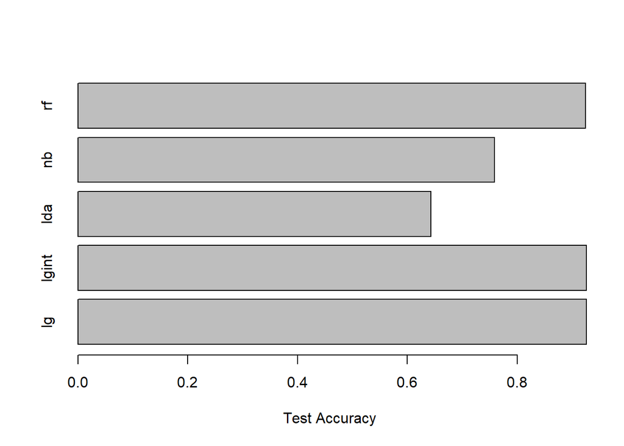

```r
barplot(unlist(results), xlab = "Test Accuracy", horiz = TRUE)
```

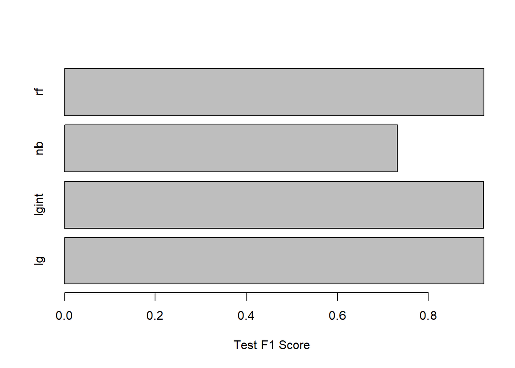

```r
barplot(unlist(results_f1), xlab = "Test F1 Score", horiz = TRUE)
```